# Creating the Tower’s Weapon

Without weapons, towers are nothing but part of the level’s environment. Towers use weapons to shoot bullets on enemies and defeat them.

In this chapter, we’re going to expand our combat system. We’ll apply properties such as cooldowns, shooting range, and projectile instancing. You’ll learn to:

- Shoot bullets using *PackedScenes*
- Find targets within a shooting range
- Shoot towards a target position
- Use cooldowns to alter a weapon’s fire rate

We start by creating the weapon itself and look at how it detects and shoots at a target. Then, we create the bullets the weapon shoots before seeing how we can add player feedback to the weapon’s attack range.

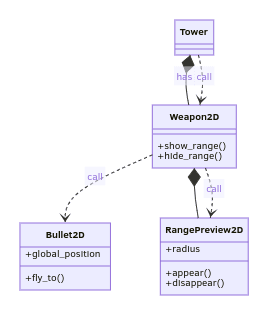

## Targeting, shooting, and limiting fire

A weapon is simply a bullet spawner. Whenever something enters a weapon’s range, it fires bullets towards the target. Its fire rate limits how many bullets it can fire per second.

Let’s start by designing the weapon scene. Since a weapon has a position, rotation, and scale in the game world, we use a *Node2D* as the scene’s root node. Name it *Weapon2D* and save it as `res://Objects/Weapon2D/Weapon2D.tscn`.

When we create instances of bullets, we should use a point in space for their position. For that, we can use a *Position2D*. It differs from *Node2D* because it has gizmos that show its transform. Let’s name it *BulletSpawnPosition2D*.

The weapon in this game is a cannon. Add a *Sprite* as a child of the *Weapon2D*. Drag the sprite sheet file at `res://sprite-sheet.svg` to the *Sprite > Texture* property.

To select the proper region of the sprite sheet, toggle on the *Region > Enabled* property. In the *TextureRegion* tab, set the *Snap Mode* to *Auto Slice*. Godot will draw the rectangles for each sprite in the sheet. Select the area that represents the cannon.

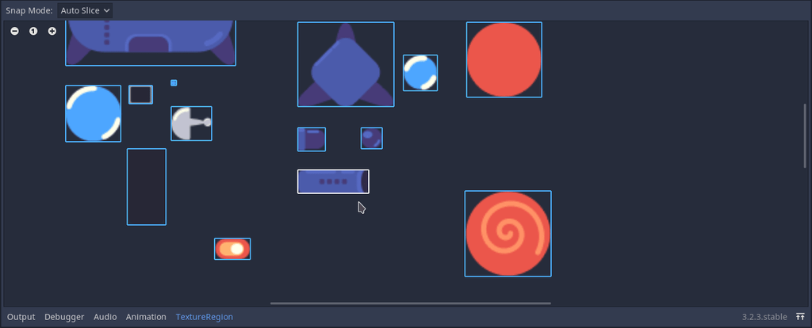

The cannon shouldn’t be at the exact center of the *Sprite* because we’re going to compose it later with the tower’s sprite in the tower chapter. Change the *Offset > x* to `40.0` to offset it horizontally.

Note you can also use the values in *Region > Rect* to locate the cannon region.

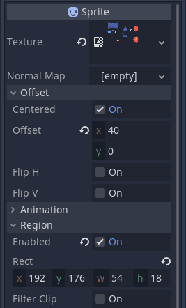

To make the bullets look like they fire from the cannon, drag the *BulletSpawnPosition2D* to the tip of the cannon.

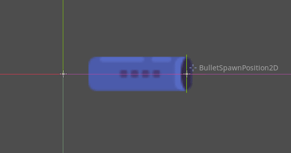

For the weapon’s attack range, we need to detect objects that enter in a radius around it. The node *Area2D* is perfect for this. We can use an *Area2D* with a *CollisionShape2D* to detect when something enters inside it like in the previous chapter.

Add a new *Area2D* as a child of the *Weapon2D* and rename it as *RangeArea2D*.

We set the mask to the *enemies* layer because it should only detect enemies in range.

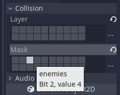

Add a *CollisionShape2D* as a child of *RangeArea2D*. Create a *Circle2D* in the *CollisionShape2D > Shape* property. Set its *Radius* to `128.0`.

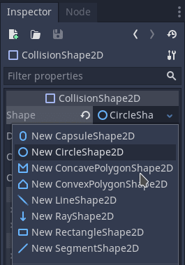

If we tried to create different weapons using this scene as a base, the collision shape will be the same for each weapon. This is because Godot shares *Resources* between instanced scenes by default. This isn’t desirable in our case as we may want to change the range of different weapons. Toggle on the *Circle2D > Local to Scene* flag.

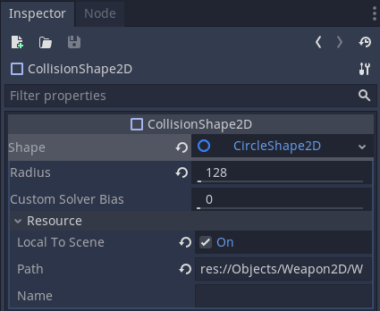

We use a *Timer* node to control the weapon’s fire rate. The *Weapon2D* will only shoot if the timer is not active. Add a new *Timer* as a child of the *Weapon2D*. We can name this node as *CooldownTimer*. Make sure to check *One Shot* so the timer doesn’t keep repeating.

Add an *AnimationPlayer* to create the shooting animation. This animation moves the *Sprite* a bit to the left and then returns it to its original position.

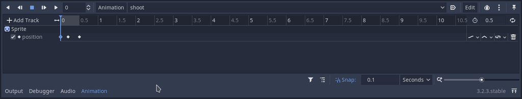

Click on the left-most track and right-click on the *Easing* property in the *Inspector*. From the dropdown menu, select the *Out* easing. This easing rapidly moves towards the final value before slowing down. It’s perfect for quick and snappy animations, like a weapon recoiling after shooting.

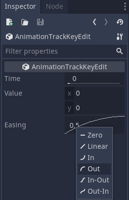

This is how the *Weapon2D*’s scene should like right now.

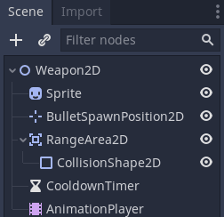

It’s time to code the weapon behavior! Attach a new GDScript to it and save it as `res://Objects/Weapon2D/Weapon2D.gd`.

We export variables so we can design weapons with different settings from the *Editor*’s *Inspector*.

Our weapon creates instances of a bullet

[figure not shown]

`PackedScene`. We export the bullet

[figure not shown]

`PackedScene` so we can swap and change it in the *Inspector*.

We export two more variables; one for the weapon’s `fire_range`, and another for the `fire_cooldown`.

After that, we cache the nodes that make up our *Weapon2D* scene, along with a reference to the *CollisionShape2D > Circle2D* resource. This will allow us to have direct access to it when we need to change the `fire_range`.

```
class_name Weapon2D
extends Node2D

export var bullet_scene: PackedScene
# Range of the weapon in pixels.
export var fire_range := 200.0 setget set_fire_range
# Cooldown in seconds to fire again
export var fire_cooldown := 1.0

onready var _bullet_spawn_position := $BulletSpawnPosition2D
onready var _cooldown_timer := $CooldownTimer
onready var _range_area := $RangeArea2D
onready var _animation_player := $AnimationPlayer
onready var _range_shape: CircleShape2D = $RangeArea2D/CollisionShape2D.shape
```

We can encapsulate the `fire_range` in a setter method to keep it synced with the *Circle2D*’s radius. In the `_ready()` callback, we update the *Circle2D*’s radius calling the `set_fire_range()` method.

```
# Ensures that the `_range_shape` has its radius up to date
func _ready() -> void:
    set_fire_range(fire_range)

# Syncs the fire_range value with the _range_shape radius
func set_fire_range(new_range: float) -> void:
    fire_range = new_range

  # Awaits for the Weapon to be ready to access the _range_shape
  # This allows us to set the fire_range through the Inspector.
    if not is_inside_tree():
        yield(self, "ready")

    _range_shape.radius = fire_range
```

Now it’s time to make our weapon shoot! Let’s create a `shoot_at()` method that receives a `target_position` as argument.

To shoot at a target, our *Weapon2D* should look at it first. Thankfully, Godot has a built-in method that handles the math for us. It’s called `look_at()` and is present on all *Node2D* nodes. It’s useful to track the mouse’s position or in our case, an enemy’s position.

We rotate the *Weapon2D* towards the `target_position` received in the `shoot_at()` method before shooting. We’ll play the `shoot` animation in the `_anim_player`. Then spawn an instance of the `bullet_scene` at the `_bullet_spawn_position.global_position`.

```
func shoot_at(target_position: Vector2) -> void:
  # Rotates the Weapon to face the target's position
    look_at(target_position)
    _animation_player.play("shoot")

  # Creates an instance of the bullet_scene at the _bullet_spawn_position
    var bullet = bullet_scene.instance()
    add_child(bullet)
    bullet.global_position = _bullet_spawn_position.global_position
```

Bullets only move towards targets; they aren’t responsible for discovering or detecting such a point.

Since the *Weapon2D* handles the target detection, it can tell the bullet where it should fly to. We’ll see how the bullets fly soon. But for now, we can assume that they have a `fly_to()` method that asks for a `target_position`.

We call the `cooldown_timer.start()` method passing the `fire_cooldown` as argument to limit the fire rate.

The weapon then notifies other classes that it’s fired a bullet. This is so that other classes can perform a behavior. We could show a clock that displays the cooldown until the next shot for example.

At the top of the script, add a `fired` signal and emit it.

```
  # Fires the bullet towards the target's position
    bullet.fly_to(target_position)

    _cooldown_timer.start(fire_cooldown)
    emit_signal("fired")
```

We have a problem if we use the *RangeArea2D*’s `area_entered` signal. If two enemies enter the area, both will trigger the signal.

The *RangeArea2D* will ignore the second target if the first dies or leaves the area because the signals don’t keep checking for targets inside of the area. Instead, we want the *Weapon2D* to check for targets inside the all the time. Unless it’s cooling down and unable to fire anyway.

The *RangeArea2D*’s `get_overlapping_areas()` method inside the `_physics_process()` returns a list of every *Area2D* inside the *RangeArea2d*. Since our weapon can only shoot a single target at a time, we take the first object in the list as our target.

We return from the `_physics_process` callback if there are no targets to shoot or the `cooldown_timer` isn’t stopped. This prevents the *Weapon2D* from shooting too much.

If the *Weapon2D* finds a target, it shoots at its position.

```
func _physics_process(_delta: float) -> void:
    if not _cooldown_timer.is_stopped():
        return

    var targets: Array = _range_area.get_overlapping_areas()

   # Returns if the list of available targets is empty
    if targets.empty():
        return

    var target: Node2D = targets[0]
    shoot_at(target.global_position)
```

### Code so far

With that, we have our essential weapon behavior in place. Before we talk about the bullets, let’s see how our code looks so far.

`Weapon2D.gd`

```
class_name Weapon2D
extends Node2D

signal fired

export var bullet_scene: PackedScene
# Range of the weapon in pixels.
export var fire_range := 128.0 setget set_fire_range
# Cooldown in seconds to fire again
export var fire_cooldown := 1.0

onready var _bullet_spawn_position := $BulletSpawnPosition2D
onready var _cooldown_timer := $CooldownTimer
onready var _range_area := $RangeArea2D
onready var _animation_player := $AnimationPlayer
onready var _range_shape: CircleShape2D = $RangeArea2D/CollisionShape2D.shape


func _ready() -> void:
    set_fire_range(fire_range)


func _physics_process(_delta: float) -> void:
    if not _cooldown_timer.is_stopped():
        return

    var targets: Array = _range_area.get_overlapping_areas()
    if targets.empty():
        return

    var target: Node2D = targets[0]
    shoot_at(target.global_position)


func set_fire_range(new_range: float) -> void:
    fire_range = new_range
    if not is_inside_tree():
        yield(self, "ready")
    _range_shape.radius = fire_range


func shoot_at(target_position: Vector2) -> void:
    look_at(target_position)
    _animation_player.play("shoot")

    var bullet = bullet_scene.instance()
    add_child(bullet)
    bullet.global_position = _bullet_spawn_position.global_position
    bullet.fly_to(target_position)

    _cooldown_timer.start(fire_cooldown)
    emit_signal("fired")
```